# Prediksi Kasus ISPA di Jakarta Berdasarkan Kualitas Udara dan Faktor Meteorologi

Nico Handoko dan Annisa Meta Nadjwa

2026-04-11

```r
library(readr)
library(tidyr)
library(lubridate)
library(zoo)
```

```r
library(moments)
library(ggplot2)
library(car)
library(mgcv)
library(corrplot)
library(forecast)
library(forcats)
library(tseries)
library(lmtest)
library(e1071)
library(xgboost)
library(iml)
library(MASS)
library(lmtest)
library(nlme)
library(dplyr)
```

# Bagian A. Data Pre-Processing

## A.1. Import Data

```r
# Data ISPU, ISPU2, Cuaca, dan ISPA
data_ispu <- read.table("ispu.csv", sep=";", header=T, stringsAsFactors = FALSE, na = c("N/A", "", "NA"))
data_ispu2 <- read.csv2("ispu_ff.csv", sep=";", header=T, stringsAsFactors = FALSE, na = c("N/A", "", "NA"))
data_cuaca <- read.table("cuaca.csv", sep=";", header=T, na = c("N/A", "", "NA"))
data_ispa <- read.csv("ispa.csv", sep=",", header=T, na = c("N/A", "", "NA"))
```

## A.1.1. Cek Struktur Dataset

```r
# Mengecek struktur dataset yang sudah diinput ke dalam RStudio
str(data_ispu)
```

```
## 'data.frame':    7150 obs. of  11 variables:
##  $ Tanggal : chr  "01/01/2021" "01/01/2021" "01/01/2021" "01/01/2021" ...
##  $ Stasiun : chr  "DKI1 (Bunderan HI)" "DKI2 (Kelapa Gading)" "DKI3 (Jagakarsa)" "DKI4 (Lubang Buaya)" ...
##  $ PM2.5   : num  53 58 56 NA NA 46 46 86 NA NA ...
##  $ PM10    : num  38 38 43 41 37 27 29 58 44 33 ...
##  $ SO2     : num  29 2 15 37 20 27 NA 15 38 18 ...
##  $ CO      : num  6 11 10 14 12 7 12 22 38 20 ...
##  $ O3      : num  31 65 33 35 25 47 80 38 59 64 ...
##  $ NO2     : num  13 6 5 4 4 7 12 5 3 6 ...
##  $ MAX     : num  53 65 56 41 37 47 80 86 59 64 ...
##  $ CRITICAL: chr  "PM25" "O3" "PM25" "PM10" ...
##  $ CATEGORY: chr  "SEDANG" "SEDANG" "SEDANG" "BAIK" ...
```

```r
summary(data_ispu)
```

```
##    Tanggal            Stasiun              PM2.5             PM10
##  Length:7150        Length:7150        Min.   : 10.00   Min.   :  3.00
##  Class :character   Class :character   1st Qu.: 59.00   1st Qu.: 39.00
##  Mode  :character   Mode  :character   Median : 75.00   Median : 53.00
##                                        Mean   : 74.58   Mean   : 50.69
##                                        3rd Qu.: 89.00   3rd Qu.: 61.00
##                                        Max.   :287.00   Max.   :187.00
##                                        NA's   :455      NA's   :553
##       SO2               CO              O3              NO2
##  Min.   :  2.00   Min.   : 1.00   Min.   :  2.00   Min.   :  1.0
##  1st Qu.: 25.00   1st Qu.: 9.00   1st Qu.: 17.00   1st Qu.: 13.0
##  Median : 34.00   Median :12.00   Median : 24.00   Median : 20.0
##  Mean   : 36.35   Mean   :13.67   Mean   : 26.95   Mean   : 22.9
##  3rd Qu.: 51.00   3rd Qu.:17.00   3rd Qu.: 33.00   3rd Qu.: 30.0
##  Max.   :112.00   Max.   :70.00   Max.   :151.00   Max.   :202.0
##  NA's   :208      NA's   :129     NA's   :142      NA's   :170
##       MAX          CRITICAL           CATEGORY
##  Min.   :  0.0   Length:7150        Length:7150
##  1st Qu.: 59.0   Class :character   Class :character
##  Median : 74.0   Mode  :character   Mode  :character
##  Mean   : 74.4
##  3rd Qu.: 89.0
##  Max.   :287.0
##  NA's   :29
```

```r
str(data_ispu2)
```

```
## 'data.frame':    365 obs. of  11 variables:
##  $ Tanggal : chr  "01/01/2022" "02/01/2022" "03/01/2022" "04/01/2022" ...
##  $ Stasiun : chr  "DKI4 (Lubang Buaya)" "DKI4 (Lubang Buaya)" "DKI4 (Lubang Buaya)" "DKI4 (Lubang Buaya)" ...
##  $ PM2.5   : int  85 70 80 102 165 117 113 77 82 87 ...
##  $ PM10    : int  57 40 49 59 95 73 71 55 56 60 ...
##  $ SO2     : int  48 45 49 51 53 53 48 52 52 51 ...
##  $ CO      : int  13 10 13 14 18 16 22 17 14 13 ...
##  $ O3      : int  34 36 37 51 55 48 38 41 39 36 ...
##  $ NO2     : int  18 11 21 26 32 42 41 29 27 26 ...
##  $ MAX     : int  85 70 80 102 165 117 113 77 82 87 ...
##  $ CRITICAL: chr  "PM2,5" "PM2,5" "PM2,5" "PM2,5" ...
##  $ CATEGORY: chr  "SEDANG" "SEDANG" "SEDANG" "TIDAK SEHAT" ...
```

```r
summary(data_ispu2)
```

```
##    Tanggal            Stasiun              PM2.5             PM10
##  Length:365         Length:365         Min.   : 40.00   Min.   :23.00
##  Class :character   Class :character   1st Qu.: 75.00   1st Qu.:52.00
##  Mode  :character   Mode  :character   Median : 92.00   Median :60.00
##                                        Mean   : 92.94   Mean   :59.82
##                                        3rd Qu.:111.00   3rd Qu.:68.00
##                                        Max.   :165.00   Max.   :95.00
##       SO2              CO              O3              NO2
##  Min.   :37.00   Min.   : 7.00   Min.   : 15.00   Min.   : 6.00
##  1st Qu.:44.00   1st Qu.:14.00   1st Qu.: 39.00   1st Qu.:23.00
##  Median :49.00   Median :17.00   Median : 54.00   Median :28.00
##  Mean   :47.93   Mean   :18.42   Mean   : 57.24   Mean   :28.75
##  3rd Qu.:51.00   3rd Qu.:21.00   3rd Qu.: 71.00   3rd Qu.:34.00
##  Max.   :62.00   Max.   :55.00   Max.   :181.00   Max.   :52.00
##       MAX           CRITICAL           CATEGORY
##  Min.   : 49.00   Length:365         Length:365
##  1st Qu.: 76.00   Class :character   Class :character
##  Median : 93.00   Mode  :character   Mode  :character
##  Mean   : 93.85
##  3rd Qu.:111.00
##  Max.   :181.00
```

```r
str(data_cuaca)
```

```
## 'data.frame':    9130 obs. of  24 variables:
##  $ Tanggal                             : chr  "01/01/2021" "01/01/2021" "01/01/2021" "01/01/2021" ...
##  $ Stasiun                             : chr  "DKI 1 (Bundaran HI)" "DKI 2 (Kelapa Gading)" "DKI 3 (Jagakarsa)" "DKI 4 (Lubang Buaya)" ...
##  $ Suhu.Maksimum                       : num  29.8 28.9 28.9 29.4 29.6 29.4 28.8 29.6 29.4 29.6 ...
##  $ Suhu.Minimum                        : num  23.5 23.9 23.1 23.1 23.5 23.9 24.4 22.6 23 23.8 ...
##  $ Total.Curah.Hujan                   : num  12.4 4.7 8.5 12.8 11.2 1.1 0.8 2.8 1.6 3.6 ...
##  $ Waktu.Hujan                         : num  16 13 9 15 15 7 3 9 7 5 ...
##  $ Kecepatan.Angin.Maksimum            : num  15.3 15.8 15.3 14.3 14.6 12 14.4 11.5 13.1 10.5 ...
##  $ Arah.Angin.Dominan                  : int  270 270 277 278 268 281 285 275 277 281 ...
##  $ Radiasi.Matahari                    : num  14.2 14.6 14.7 14.6 13.8 ...
##  $ Suhu.Rata.Rata                      : num  25.7 26 25.4 25.4 25.7 26.6 26.8 25.9 26.1 26.6 ...
##  $ Kelembaban.Rata.Rata                : int  88 86 87 89 88 82 81 85 83 82 ...
##  $ Tutupan.Awan.Rata.Rata              : int  97 98 96 97 96 91 94 89 91 91 ...
##  $ Tekanan.Udara.Rata.Rata             : num  1008 1008 1001 1005 1007 ...
##  $ Kecepatan.Hembusan.Angin.Rata.rata  : num  37.4 42.8 40.3 38.9 37.1 28.4 32.4 29.5 30.2 26.6 ...
##  $ Kelembaban.Maksimum                 : int  96 96 97 97 97 93 90 97 94 93 ...
##  $ Kelembaban.Minimum                  : int  69 74 73 74 70 69 71 68 69 68 ...
##  $ Tutupan.Awan.Maksimum               : int  100 100 100 100 100 100 100 100 100 100 ...
##  $ Tutupan.Awan.Minimum                : int  90 91 88 90 75 42 74 46 52 59 ...
##  $ Kecepatan.Hembusan.Angin.Rata.rata.1: num  21.6 25.3 23.9 24.2 21.8 16.5 21.2 16.6 17.4 16.9 ...
##  $ Kecepatan.Angin.Rata.rata           : num  7.9 10.3 10 9.3 7.8 7 9.7 6.6 7.6 7.1 ...
##  $ Kecepatan.Hembusan.Angin.Minimum    : num  9.7 16.2 12.2 11.9 10.8 5.4 8.6 4.7 4.3 6.5 ...
##  $ Kecepatan.Angin.Minimum             : num  5.5 7.8 6.2 6.2 5.4 2.5 4.6 2.3 3.6 4.3 ...
##  $ Tekanan.Udara.Maksimum              : num  1009 1009 1002 1006 1008 ...
##  $ Tekanan.Udara.Minimum               : num  1006 1006 999 1003 1006 ...
```

```r
summary(data_cuaca)
```

```
##    Tanggal            Stasiun          Suhu.Maksimum    Suhu.Minimum
##  Length:9130        Length:9130        Min.   :24.80   Min.   :19.20
##  Class :character   Class :character   1st Qu.:30.20   1st Qu.:23.00
##  Mode  :character   Mode  :character   Median :31.40   Median :23.60
##                                        Mean   :31.36   Mean   :23.61
##                                        3rd Qu.:32.40   3rd Qu.:24.20
##                                        Max.   :38.80   Max.   :27.40
##  Total.Curah.Hujan  Waktu.Hujan     Kecepatan.Angin.Maksimum Arah.Angin.Dominan
##  Min.   :  0.000   Min.   : 0.000   Min.   : 4.10            Min.   :  0.0
##  1st Qu.:  1.100   1st Qu.: 4.000   1st Qu.:10.20            1st Qu.:103.0
##  Median :  4.300   Median : 7.000   Median :12.30            Median :214.0
##  Mean   :  7.226   Mean   : 7.941   Mean   :12.81            Mean   :190.4
##  3rd Qu.: 10.800   3rd Qu.:11.000   3rd Qu.:15.00            3rd Qu.:268.0
##  Max.   :107.000   Max.   :24.000   Max.   :27.50            Max.   :360.0
##  Radiasi.Matahari Suhu.Rata.Rata  Kelembaban.Rata.Rata Tutupan.Awan.Rata.Rata
##  Min.   : 3.21    Min.   :23.60   Min.   :51.00        Min.   :  1.00
##  1st Qu.:16.74    1st Qu.:26.20   1st Qu.:78.00        1st Qu.: 69.00
##  Median :19.17    Median :26.80   Median :83.00        Median : 89.00
##  Mean   :18.57    Mean   :26.84   Mean   :81.53        Mean   : 80.52
##  3rd Qu.:21.15    3rd Qu.:27.50   3rd Qu.:86.00        3rd Qu.: 98.00
##  Max.   :26.82    Max.   :30.80   Max.   :95.00        Max.   :100.00
##  Tekanan.Udara.Rata.Rata Kecepatan.Hembusan.Angin.Rata.rata Kelembaban.Maksimum
##  Min.   : 998.2          Min.   :13.30                      Min.   : 72.00
##  1st Qu.:1004.9          1st Qu.:25.90                      1st Qu.: 93.00
##  Median :1007.5          Median :30.20                      Median : 96.00
##  Mean   :1006.8          Mean   :30.98                      Mean   : 95.02
##  3rd Qu.:1009.1          3rd Qu.:35.60                      3rd Qu.: 98.00
##  Max.   :1013.0          Max.   :68.40                      Max.   :100.00
##  Kelembaban.Minimum Tutupan.Awan.Maksimum Tutupan.Awan.Minimum
##  Min.   :20.00      Min.   : 16.00        Min.   :  0.00
##  1st Qu.:55.00      1st Qu.:100.00        1st Qu.:  8.00
##  Median :63.00      Median :100.00        Median : 31.00
##  Mean   :61.18      Mean   : 98.58        Mean   : 42.81
##  3rd Qu.:69.00      3rd Qu.:100.00        3rd Qu.: 82.00
##  Max.   :91.00      Max.   :100.00        Max.   :100.00
##  Kecepatan.Hembusan.Angin.Rata.rata.1 Kecepatan.Angin.Rata.rata
##  Min.   : 8.60                        Min.   : 2.20
##  1st Qu.:13.30                        1st Qu.: 4.80
##  Median :15.20                        Median : 5.80
##  Mean   :16.43                        Mean   : 6.42
##  3rd Qu.:18.20                        3rd Qu.: 7.30
##  Max.   :46.70                        Max.   :18.60
##  Kecepatan.Hembusan.Angin.Minimum Kecepatan.Angin.Minimum
##  Min.   : 0.700                   Min.   : 0.000
##  1st Qu.: 4.300                   1st Qu.: 1.000
##  Median : 5.400                   Median : 1.600
##  Mean   : 6.292                   Mean   : 2.147
##  3rd Qu.: 6.800                   3rd Qu.: 2.700
##  Max.   :30.600                   Max.   :14.300
##  Tekanan.Udara.Maksimum Tekanan.Udara.Minimum
##  Min.   : 999.6         Min.   : 995.8
##  1st Qu.:1006.7         1st Qu.:1002.6
##  Median :1009.3         Median :1005.2
##  Mean   :1008.6         Mean   :1004.5
##  3rd Qu.:1010.9         3rd Qu.:1006.8
##  Max.   :1015.2         Max.   :1011.0
```

```r
str(data_ispa)
```

```
## 'data.frame':    60 obs. of  3 variables:
##  $ X        : int  1 2 3 4 5 6 7 8 9 10 ...
##  $ Case_ISPA: num  35 37 40 42 39 60 50 32 45 45 ...
##  $ bulan    : chr  "2021-01-01" "2021-02-01" "2021-03-01" "2021-04-01" ...
```

```r
summary(data_ispa)
```

```
##        X           Case_ISPA        bulan
##  Min.   : 1.00   Min.   : 32.0   Length:60
##  1st Qu.:15.75   1st Qu.: 80.0   Class :character
##  Median :30.50   Median :119.9   Mode  :character
##  Mean   :30.50   Mean   :116.5
##  3rd Qu.:45.25   3rd Qu.:150.0
##  Max.   :60.00   Max.   :249.3
```

## A.2. Data Cleaning

### A.2.1. Imputasi Missing Value & Gabungkan Kedua Data ISPU

```r
# Mengubah tipe variabel Tanggal
data_ispu$Tanggal <- dmy(data_ispu$Tanggal)
data_ispu2$Tanggal <- dmy(data_ispu2$Tanggal)
```

```r
# Mengecek tipe data variabel Tanggal
class(data_ispu$Tanggal)
```

```
## [1] "Date"
```

```r
class(data_ispu2$Tanggal)
```

```
## [1] "Date"
```

```r
# Mengecek jangkauan tanggal dari data ispu
range(data_ispu$Tanggal)
```

```
## [1] "2021-01-01" "2025-11-30"
```

```r
range(data_ispu2$Tanggal)
```

```
## [1] "2022-01-01" "2022-12-31"
```

```r
# Mengecek data Missing Values pada seluruh data ispu
colSums(is.na(data_ispu))
```

```
##  Tanggal  Stasiun    PM2.5     PM10      SO2       CO       O3      NO2
##        0        0      455      553      208      129      142      170
##      MAX CRITICAL CATEGORY
##       29       61        0
```

```r
colSums(is.na(data_ispu2))
```

```
##  Tanggal  Stasiun    PM2.5     PM10      SO2       CO       O3      NO2
##        0        0        0        0        0        0        0        0
##      MAX CRITICAL CATEGORY
##        0        0        0
```

```r
# Mengisi variabel yang kosong dengan nilai aproksimasi/perkiraan
data_ispu$PM2.5 <- na.approx(data_ispu$PM2.5, na.rm = FALSE)
data_ispu$PM10 <- na.approx(data_ispu$PM10, na.rm = FALSE)
data_ispu$SO2  <- na.approx(data_ispu$SO2, na.rm = FALSE)
data_ispu$CO   <- na.approx(data_ispu$CO, na.rm = FALSE)
data_ispu$O3   <- na.approx(data_ispu$O3, na.rm = FALSE)
data_ispu$NO2  <- na.approx(data_ispu$NO2, na.rm = FALSE)
```

```r
# Mengisi stasiun
data_ispu <- data_ispu %>% fill(Stasiun, .direction = "downup")
```

```r
# Mengubah nilai max yang terbaru dari variabel polutan
data_ispu$MAX <- pmax(data_ispu$PM2.5, data_ispu$PM10, data_ispu$SO2, data_ispu$CO, data_ispu$O3, data_ispu$NO2, na.rm = TRUE)
```

```r
# Mengubah variabel critical yang terbaru
data_ispu$CRITICAL <- colnames(
  data_ispu[,c("PM2.5","PM10","SO2","CO","O3","NO2")]
)[max.col(
  data_ispu[,c("PM2.5","PM10","SO2","CO","O3","NO2")],
  ties.method = "first"
)]
```

```r
# Mengubah variabel Category yang terbaru
data_ispu$CATEGORY <- case_when(
  data_ispu$MAX <= 50 ~ "Good",
  data_ispu$MAX <= 100 ~ "Moderate",
  data_ispu$MAX <= 200 ~ "Unhealthly",
  data_ispu$MAX <= 300 ~ "Very Unhealthly",
  TRUE ~ "Hazardous"
)
```

```r
# Mengecek apakah variabel data ispu masih terdapat data yang kosong
colSums(is.na(data_ispu))
```

```
##  Tanggal  Stasiun    PM2.5     PM10      SO2       CO       O3      NO2
##        0        0        0        0        0        0        0        0
##      MAX CRITICAL CATEGORY
##        0        0        0
```

```r
# Memperbaiki nilai variabel MAX, CRITICAL, dan CATEGORY di data_ispu2
data_ispu2$MAX <- pmax(data_ispu2$PM2.5, data_ispu2$PM10, data_ispu2$SO2, data_ispu2$CO, data_ispu2$O3, data_ispu2$NO2, na.rm = TRUE)

data_ispu2$CRITICAL <- colnames(
  data_ispu2[,c("PM2.5","PM10","SO2","CO","O3","NO2")]
)[max.col(
  data_ispu2[,c("PM2.5","PM10","SO2","CO","O3","NO2")],
  ties.method = "first"
)]

data_ispu2$CATEGORY <- case_when(
  data_ispu2$MAX <= 50 ~ "Good",
  data_ispu2$MAX <= 100 ~ "Moderate",
  data_ispu2$MAX <= 200 ~ "Unhealthly",
  data_ispu2$MAX <= 300 ~ "Very Unhealthly",
  TRUE ~ "Hazardous"
)
```

```r
# Menghitung nilai rata-rata per stasiun dari variabel ISPU
ispu_harian <- data_ispu %>%
  group_by(Tanggal) %>%
  summarise(
    PM2.5 = mean(PM2.5, na.rm = TRUE),
    PM10 = mean(PM10, na.rm = TRUE),
    SO2  = mean(SO2, na.rm = TRUE),
    CO   = mean(CO, na.rm = TRUE),
    O3   = mean(O3, na.rm = TRUE),
    NO2  = mean(NO2, na.rm = TRUE)
  )

# Menambahkan variabel MAX, CRITICAL, dan CATEGORY di ispu_harian
ispu_harian$MAX <- pmax(ispu_harian$PM2.5, ispu_harian$PM10, ispu_harian$SO2, ispu_harian$CO, ispu_harian$O3, ispu_harian$NO2, na.rm = TRUE)

ispu_harian$CRITICAL <- colnames(
  ispu_harian[,c("PM2.5","PM10","SO2","CO","O3","NO2")]
)[max.col(
  ispu_harian[,c("PM2.5","PM10","SO2","CO","O3","NO2")],
  ties.method = "first"
)]

ispu_harian$CATEGORY <- case_when(
  ispu_harian$MAX <= 50 ~ "Good",
  ispu_harian$MAX <= 100 ~ "Moderate",
  ispu_harian$MAX <= 200 ~ "Unhealthly",
  ispu_harian$MAX <= 300 ~ "Very Unhealthly",
  TRUE ~ "Hazardous"
)
```

```r
# Menghitung nilai rata-rata per stasiun dari data_ispu2
ispu_harian2 <- data_ispu2 %>%
  group_by(Tanggal) %>%
  summarise(
    PM2.5 = mean(PM2.5, na.rm = TRUE),
    PM10 = mean(PM10, na.rm = TRUE),
    SO2  = mean(SO2, na.rm = TRUE),
    CO   = mean(CO, na.rm = TRUE),
    O3   = mean(O3, na.rm = TRUE),
    NO2  = mean(NO2, na.rm = TRUE)
  )

# Menambahkan variabel MAX, CRITICAL, dan CATEGORY di ispu_harian2
ispu_harian2$MAX <- pmax(ispu_harian2$PM2.5, ispu_harian2$PM10, ispu_harian2$SO2, ispu_harian2$CO, ispu_harian2$O3, ispu_harian2$NO2, na.rm = TRUE)

ispu_harian2$CRITICAL <- colnames(
  ispu_harian2[,c("PM2.5","PM10","SO2","CO","O3","NO2")]
)[max.col(
  ispu_harian2[,c("PM2.5","PM10","SO2","CO","O3","NO2")],
  ties.method = "first"
)]

ispu_harian2$CATEGORY <- case_when(
  ispu_harian2$MAX <= 50 ~ "Good",
  ispu_harian2$MAX <= 100 ~ "Moderate",
  ispu_harian2$MAX <= 200 ~ "Unhealthly",
  ispu_harian2$MAX <= 300 ~ "Very Unhealthly",
  TRUE ~ "Hazardous"
)
```

```r
# Gabungkan data ispu_harian & ispu_harian2
ispu_harian_gabung <- bind_rows(ispu_harian, ispu_harian2)
```

```r
# Gabungkan data ispu & ispu2
ispu_gabung <- bind_rows(data_ispu, data_ispu2)
```

### A.2.2. Imputasi Missing Value Data Cuaca

```r
# Mengecek variabel data_cuaca
str(data_cuaca)
```

```
## 'data.frame':    9130 obs. of  24 variables:
##  $ Tanggal                             : chr  "01/01/2021" "01/01/2021" "01/01/2021" "01/01/2021" ...
##  $ Stasiun                             : chr  "DKI 1 (Bundaran HI)" "DKI 2 (Kelapa Gading)" "DKI 3 (Jagakarsa)" "DKI 4 (Lubang Buaya)" ...
##  $ Suhu.Maksimum                       : num  29.8 28.9 28.9 29.4 29.6 29.4 28.8 29.6 29.4 29.6 ...
##  $ Suhu.Minimum                        : num  23.5 23.9 23.1 23.1 23.5 23.9 24.4 22.6 23 23.8 ...
##  $ Total.Curah.Hujan                   : num  12.4 4.7 8.5 12.8 11.2 1.1 0.8 2.8 1.6 3.6 ...
##  $ Waktu.Hujan                         : num  16 13 9 15 15 7 3 9 7 5 ...
##  $ Kecepatan.Angin.Maksimum            : num  15.3 15.8 15.3 14.3 14.6 12 14.4 11.5 13.1 10.5 ...
##  $ Arah.Angin.Dominan                  : int  270 270 277 278 268 281 285 275 277 281 ...
##  $ Radiasi.Matahari                    : num  14.2 14.6 14.7 14.6 13.8 ...
##  $ Suhu.Rata.Rata                      : num  25.7 26 25.4 25.4 25.7 26.6 26.8 25.9 26.1 26.6 ...
##  $ Kelembaban.Rata.Rata                : int  88 86 87 89 88 82 81 85 83 82 ...
##  $ Tutupan.Awan.Rata.Rata              : int  97 98 96 97 96 91 94 89 91 91 ...
##  $ Tekanan.Udara.Rata.Rata             : num  1008 1008 1001 1005 1007 ...
##  $ Kecepatan.Hembusan.Angin.Rata.rata  : num  37.4 42.8 40.3 38.9 37.1 28.4 32.4 29.5 30.2 26.6 ...
##  $ Kelembaban.Maksimum                 : int  96 96 97 97 97 93 90 97 94 93 ...
##  $ Kelembaban.Minimum                  : int  69 74 73 74 70 69 71 68 69 68 ...
##  $ Tutupan.Awan.Maksimum               : int  100 100 100 100 100 100 100 100 100 100 ...
##  $ Tutupan.Awan.Minimum                : int  90 91 88 90 75 42 74 46 52 59 ...
##  $ Kecepatan.Hembusan.Angin.Rata.rata.1: num  21.6 25.3 23.9 24.2 21.8 16.5 21.2 16.6 17.4 16.9 ...
##  $ Kecepatan.Angin.Rata.rata           : num  7.9 10.3 10 9.3 7.8 7 9.7 6.6 7.6 7.1 ...
##  $ Kecepatan.Hembusan.Angin.Minimum    : num  9.7 16.2 12.2 11.9 10.8 5.4 8.6 4.7 4.3 6.5 ...
##  $ Kecepatan.Angin.Minimum             : num  5.5 7.8 6.2 6.2 5.4 2.5 4.6 2.3 3.6 4.3 ...
##  $ Tekanan.Udara.Maksimum              : num  1009 1009 1002 1006 1008 ...
##  $ Tekanan.Udara.Minimum               : num  1006 1006 999 1003 1006 ...
```

```r
# Mengubah tipe variabel Tanggal
data_cuaca$Tanggal <- dmy(data_cuaca$Tanggal)

# Tipe data yang masih int akan diubah ke dalam num dari variabel cuaca
cols_temp <- c("Kelembaban.Rata.Rata", "Tutupan.Awan.Rata.Rata")

data_cuaca[cols_temp] <- lapply(data_cuaca[cols_temp], as.numeric)
```

```r
# Mengecek nilai variabel pada data cuaca
colSums(is.na(data_cuaca))
```

```
##                              Tanggal                              Stasiun
##                                    0                                    0
##                        Suhu.Maksimum                         Suhu.Minimum
##                                    0                                    0
##                    Total.Curah.Hujan                          Waktu.Hujan
##                                    0                                    0
##             Kecepatan.Angin.Maksimum                   Arah.Angin.Dominan
##                                    0                                    0
##                     Radiasi.Matahari                       Suhu.Rata.Rata
##                                    0                                    0
##                 Kelembaban.Rata.Rata               Tutupan.Awan.Rata.Rata
##                                    0                                    0
##              Tekanan.Udara.Rata.Rata   Kecepatan.Hembusan.Angin.Rata.rata
##                                    0                                    0
##                  Kelembaban.Maksimum                   Kelembaban.Minimum
##                                    0                                    0
##                Tutupan.Awan.Maksimum                 Tutupan.Awan.Minimum
##                                    0                                    0
## Kecepatan.Hembusan.Angin.Rata.rata.1            Kecepatan.Angin.Rata.rata
##                                    0                                    0
##     Kecepatan.Hembusan.Angin.Minimum              Kecepatan.Angin.Minimum
##                                    0                                    0
##               Tekanan.Udara.Maksimum                Tekanan.Udara.Minimum
##                                    0                                    0
```

```r
# Menghapus variabel yang tidak dibutuhkan pada data cuaca
# data_cuaca <- data_cuaca %>% select(Tanggal, Stasiun, Suhu.Rata.Rata, Kelembaban.Rata.Rata ,Total.Curah.Hujan, Tutupan.Awan.Rata.Rata, Kecepatan.Angin.Rata.rata, Tekanan.Udara.Rata.Rata)
```

```r
# Mengubah nama variabel pada data cuaca
data_cuaca <- data_cuaca %>%
  rename(
    TEMP = Suhu.Rata.Rata,
    HUM = Kelembaban.Rata.Rata,
    RAIN = Total.Curah.Hujan,
    CC = Tutupan.Awan.Rata.Rata,
    WSPM = Kecepatan.Angin.Rata.rata,
    PRES = Tekanan.Udara.Rata.Rata
  )
```

```r
# Mengecek tipe data variabel pada data cuaca
str(data_cuaca)
```

```
## 'data.frame':    9130 obs. of  24 variables:
##  $ Tanggal                             : Date, format: "2021-01-01" "2021-01-01" ...
##  $ Stasiun                             : chr  "DKI 1 (Bundaran HI)" "DKI 2 (Kelapa Gading)" "DKI 3 (Jagakarsa)" "DKI 4 (Lubang Buaya)" ...
##  $ Suhu.Maksimum                       : num  29.8 28.9 28.9 29.4 29.6 29.4 28.8 29.6 29.4 29.6 ...
##  $ Suhu.Minimum                        : num  23.5 23.9 23.1 23.1 23.5 23.9 24.4 22.6 23 23.8 ...
##  $ RAIN                                : num  12.4 4.7 8.5 12.8 11.2 1.1 0.8 2.8 1.6 3.6 ...
##  $ Waktu.Hujan                         : num  16 13 9 15 15 7 3 9 7 5 ...
##  $ Kecepatan.Angin.Maksimum            : num  15.3 15.8 15.3 14.3 14.6 12 14.4 11.5 13.1 10.5 ...
##  $ Arah.Angin.Dominan                  : int  270 270 277 278 268 281 285 275 277 281 ...
##  $ Radiasi.Matahari                    : num  14.2 14.6 14.7 14.6 13.8 ...
##  $ TEMP                                : num  25.7 26 25.4 25.4 25.7 26.6 26.8 25.9 26.1 26.6 ...
##  $ HUM                                 : num  88 86 87 89 88 82 81 85 83 82 ...
##  $ CC                                  : num  97 98 96 97 96 91 94 89 91 91 ...
##  $ PRES                                : num  1008 1008 1001 1005 1007 ...
##  $ Kecepatan.Hembusan.Angin.Rata.rata  : num  37.4 42.8 40.3 38.9 37.1 28.4 32.4 29.5 30.2 26.6 ...
##  $ Kelembaban.Maksimum                 : int  96 96 97 97 97 93 90 97 94 93 ...
##  $ Kelembaban.Minimum                  : int  69 74 73 74 70 69 71 68 69 68 ...
##  $ Tutupan.Awan.Maksimum               : int  100 100 100 100 100 100 100 100 100 100 ...
##  $ Tutupan.Awan.Minimum                : int  90 91 88 90 75 42 74 46 52 59 ...
##  $ Kecepatan.Hembusan.Angin.Rata.rata.1: num  21.6 25.3 23.9 24.2 21.8 16.5 21.2 16.6 17.4 16.9 ...
##  $ WSPM                                : num  7.9 10.3 10 9.3 7.8 7 9.7 6.6 7.6 7.1 ...
##  $ Kecepatan.Hembusan.Angin.Minimum    : num  9.7 16.2 12.2 11.9 10.8 5.4 8.6 4.7 4.3 6.5 ...
##  $ Kecepatan.Angin.Minimum             : num  5.5 7.8 6.2 6.2 5.4 2.5 4.6 2.3 3.6 4.3 ...
##  $ Tekanan.Udara.Maksimum              : num  1009 1009 1002 1006 1008 ...
##  $ Tekanan.Udara.Minimum               : num  1006 1006 999 1003 1006 ...
```

```r
library(dplyr)
```

```r
# Mengubah data cuaca dari nilai 5 stasiun menjadi nilai rata-rata per hari sesuai dengan variabel data cuaca
cuaca_harian <- data_cuaca %>%
  group_by(Tanggal) %>%
  summarise(
    TEMP = mean(TEMP, na.rm = TRUE),
    HUM = mean(HUM, na.rm = TRUE),
    RAIN = mean(RAIN, na.rm = TRUE),
    CC = mean(CC, na.rm = TRUE),
    WSPM = mean(WSPM, na.rm = TRUE),
    PRES = mean(PRES, na.rm = TRUE)
  )
```

```r
# Download Data Cuaca Harian, 5 Stasiun yang sama dengan ISPU
write.csv(cuaca_harian, "cuaca_harian.csv")
```

### A.2.3. Penggabungan Data ISPU Harian Dengan Data Cuaca Harian

```r
library(lubridate)
```

```r
# Gabungkan data ispu harian dengan data cuaca harian menjadi satu data
ispu_cuaca_harian <- ispu_harian_gabung %>%
  inner_join(cuaca_harian, by = "Tanggal")
```

```r
# Membuat variabel kategori hujan di data ispu_cuaca_harian
ispu_cuaca_harian <- ispu_cuaca_harian %>%
  mutate(
    RAIN_CATEGORY = case_when(
      RAIN == 0 ~ "No Rain",
      RAIN < 5 ~ "Very Light Rain",
      RAIN < 20 ~ "Light Rain",
      RAIN < 50 ~ "Moderate Rain",
      RAIN < 100 ~ "Heavy Rain",
      TRUE ~ "Very Heavy Rain"
    )
  )

# Membuat variabel kategori kelembaban di ispu_cuaca_harian
ispu_cuaca_harian <- ispu_cuaca_harian %>%
  mutate(
    HUM_CATEGORY = case_when(
      HUM < 45 ~ "Low Humidity",
      HUM < 65 ~ "Optimal Humidity",
      TRUE ~ "High Humidity"
    )
  )
```

### A.2.4. Mengecek Outlier (Boxplot per Polutan)

Sesi ini mengecek nilai outlier pada seluruh variabel ISPU.

#### A.2.4.1. Variabel PM2.5

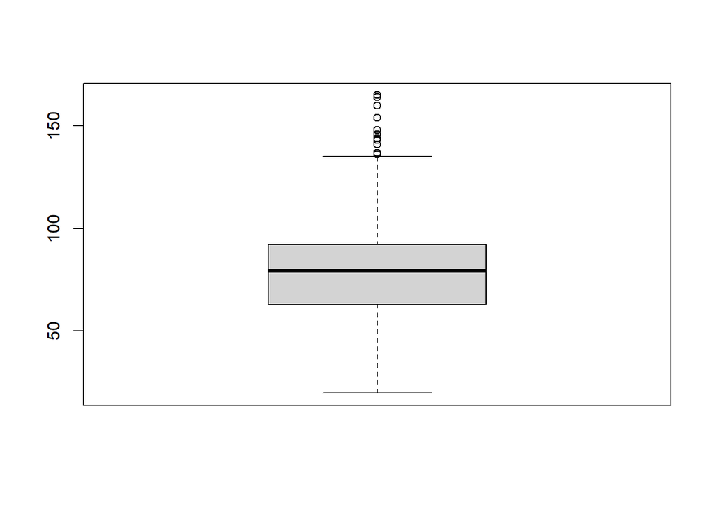

```r
boxplot(ispu_harian_gabung$PM2.5)
```

```r
boxplot.stats(ispu_harian_gabung$PM2.5)$out
```

```
##  [1] 165 141 160 164 148 136 146 136 141 146 137 143 143 141 148 144 154
```

Dari visualisasi ini terlihat terdapat data outlier dari variabel PM2.5, tetapi data ini tidak terlalu jauh dan masih memungkinkan dikarenakan bisa terjadinya polusi udara yang ekstrem.

```r
ispu_harian_gabung %>%
  filter(PM2.5 %in% boxplot.stats(PM2.5)$out)
```

| Tanggal | PM2.5 | PM10 | SO2 | CO | O3 | NO2 | MAX | CRITICAL | CATEGORY |
| --- | --- | --- | --- | --- | --- | --- | --- | --- | --- |
| 2022-01-05 | 165 | 95 | 53 | 18 | 55 | 32 | 165 | PM2.5 | Unhealthly |
| 2022-03-17 | 141 | 77 | 40 | 23 | 77 | 28 | 141 | PM2.5 | Unhealthly |
| 2022-03-31 | 160 | 95 | 49 | 34 | 137 | 34 | 160 | PM2.5 | Unhealthly |
| 2022-04-10 | 164 | 82 | 46 | 27 | 80 | 38 | 164 | PM2.5 | Unhealthly |
| 2022-04-17 | 148 | 76 | 52 | 21 | 93 | 24 | 148 | PM2.5 | Unhealthly |
| 2022-05-19 | 136 | 75 | 43 | 28 | 64 | 46 | 136 | PM2.5 | Unhealthly |
| 2022-05-27 | 146 | 79 | 52 | 25 | 76 | 35 | 146 | PM2.5 | Unhealthly |
| 2022-06-04 | 136 | 78 | 44 | 26 | 92 | 51 | 136 | PM2.5 | Unhealthly |
| 2022-06-15 | 141 | 80 | 45 | 25 | 44 | 43 | 141 | PM2.5 | Unhealthly |
| 2022-06-16 | 146 | 79 | 46 | 32 | 50 | 45 | 146 | PM2.5 | Unhealthly |

[output cut: 7 more lines]

#### A.2.4.2. Variabel PM10

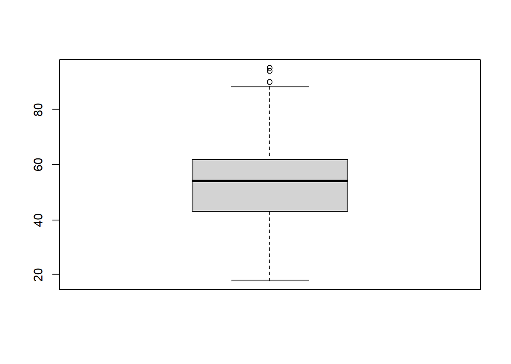

```r
boxplot(ispu_harian_gabung$PM10)
```

```r
boxplot.stats(ispu_harian_gabung$PM10)$out
```

```
## [1] 95 90 95 94
```

```r
ispu_harian_gabung %>%
  filter(PM10 %in% boxplot.stats(PM10)$out)
```

| Tanggal | PM2.5 | PM10 | SO2 | CO | O3 | NO2 | MAX | CRITICAL | CATEGORY |
| --- | --- | --- | --- | --- | --- | --- | --- | --- | --- |
| 2022-01-05 | 165 | 95 | 53 | 18 | 55 | 32 | 165 | PM2.5 | Unhealthly |
| 2022-03-25 | 122 | 90 | 51 | 19 | 70 | 29 | 122 | PM2.5 | Unhealthly |
| 2022-03-31 | 160 | 95 | 49 | 34 | 137 | 34 | 160 | PM2.5 | Unhealthly |
| 2022-07-07 | 135 | 94 | 46 | 29 | 74 | 44 | 135 | PM2.5 | Unhealthly |

Dari visualisasi ini terlihat terdapat data outlier dari variabel PM10, tetapi data ini tidak terlalu jauh dan masih memungkinkan dikarenakan bisa terjadinya polusi udara yang ekstrem.

#### A.2.4.3. Variabel SO2

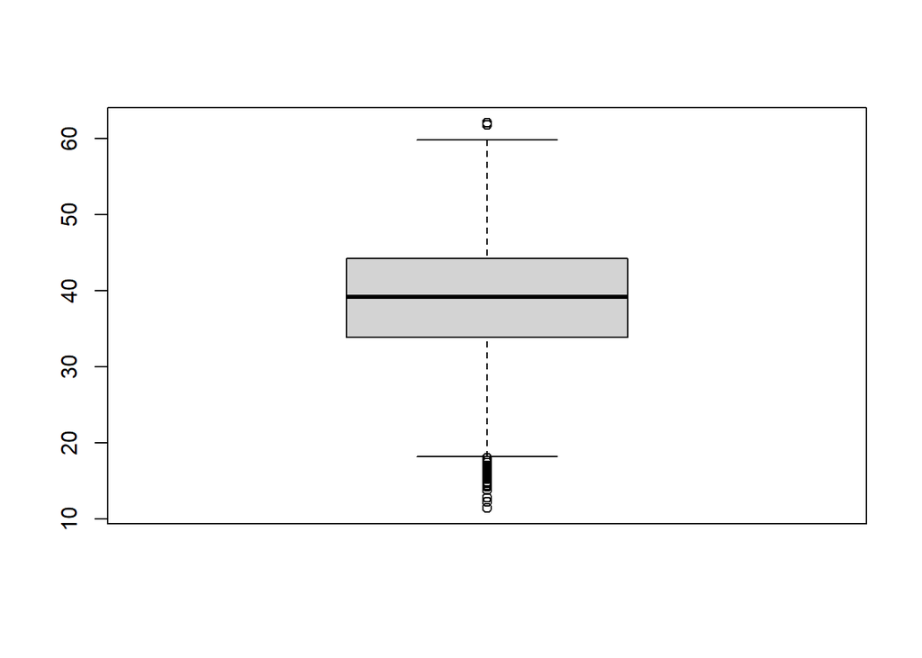

```r
boxplot(ispu_harian_gabung$SO2)
```

```r
boxplot.stats(ispu_harian_gabung$SO2)$out
```

```
##  [1] 17.0 16.6 16.0 16.8 14.7 16.5 17.6 61.8 18.0 13.8 15.6 15.2 14.8 15.6 12.8
## [16] 14.4 16.2 14.2 11.4 15.8 14.4 15.4 12.2 16.8 14.4 18.0 17.0 18.0 17.4 62.0
```

```r
ispu_harian_gabung %>%
  filter(SO2 %in% boxplot.stats(SO2)$out)
```

| Tanggal | PM2.5 | PM10 | SO2 | CO | O3 | NO2 | MAX | CRITICAL | CATEGORY |
| --- | --- | --- | --- | --- | --- | --- | --- | --- | --- |
| 2021-01-15 | 71.8 | 42.2 | 17.0 | 16.0 | 51.6 | 8.4 | 71.8 | PM2.5 | Moderate |
| 2021-01-19 | 45.8 | 31.6 | 16.6 | 8.6 | 37.2 | 7.8 | 45.8 | PM2.5 | Good |
| 2021-01-20 | 44.6 | 41.4 | 16.0 | 11.6 | 40.2 | 9.7 | 44.6 | PM2.5 | Good |
| 2021-01-21 | 51.1 | 49.4 | 16.8 | 15.6 | 42.8 | 10.4 | 51.1 | PM2.5 | Moderate |
| 2021-01-24 | 73.8 | 44.1 | 14.7 | 16.6 | 38.5 | 10.4 | 73.8 | PM2.5 | Moderate |
| 2021-01-25 | 85.6 | 58.1 | 16.5 | 26.6 | 79.4 | 12.1 | 85.6 | PM2.5 | Moderate |
| 2021-01-31 | 42.2 | 38.5 | 17.6 | 14.0 | 39.2 | 8.0 | 42.2 | PM2.5 | Good |
| 2024-12-13 | 42.2 | 24.2 | 61.8 | 9.4 | 14.6 | 11.0 | 61.8 | SO2 | Moderate |
| 2024-12-22 | 57.2 | 48.0 | 18.0 | 13.2 | 19.4 | 25.4 | 57.2 | PM2.5 | Moderate |
| 2024-12-23 | 53.4 | 47.4 | 13.8 | 15.4 | 19.0 | 34.2 | 53.4 | PM2.5 | Moderate |

[output cut: 20 more lines]

#### A.2.4.4. Variabel CO

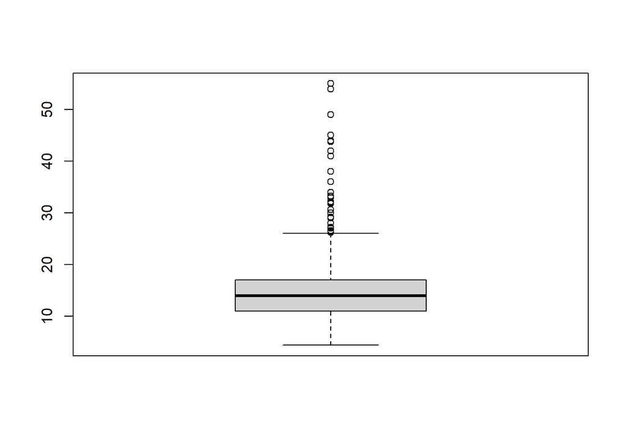

```r
boxplot(ispu_harian_gabung$CO)
```

```r
boxplot.stats(ispu_harian_gabung$CO)$out
```

```
##  [1] 29.2 43.8 26.6 27.2 30.6 31.8 31.8 26.2 26.6 29.2 26.4 32.2 33.2 26.2 30.0
## [16] 44.0 36.0 29.0 33.0 49.0 34.0 27.0 30.0 28.0 44.0 27.0 27.0 32.0 30.0 29.0
## [31] 28.0 30.0 28.0 27.0 28.0 28.0 30.0 27.0 30.0 28.0 45.0 49.0 38.0 55.0 45.0
## [46] 54.0 42.0 41.0
```

```r
ispu_harian_gabung %>%
  filter(CO %in% boxplot.stats(CO)$out)
```

| Tanggal | PM2.5 | PM10 | SO2 | CO | O3 | NO2 | MAX | CRITICAL | CATEGORY |
| --- | --- | --- | --- | --- | --- | --- | --- | --- | --- |
| 2021-01-09 | 61.4 | 45.8 | 18.4 | 29.2 | 40.4 | 10.0 | 61.4 | PM2.5 | Moderate |
| 2021-01-23 | 103.2 | 80.6 | 19.2 | 43.8 | 63.4 | 17.0 | 103.2 | PM2.5 | Unhealthly |
| 2021-01-25 | 85.6 | 58.1 | 16.5 | 26.6 | 79.4 | 12.1 | 85.6 | PM2.5 | Moderate |
| 2024-01-07 | 80.8 | 56.0 | 33.8 | 27.2 | 33.4 | 28.3 | 80.8 | PM2.5 | Moderate |
| 2024-03-10 | 83.8 | 59.6 | 34.8 | 30.6 | 19.6 | 47.4 | 83.8 | PM2.5 | Moderate |
| 2024-03-23 | 108.0 | 64.2 | 34.2 | 31.8 | 29.2 | 53.0 | 108.0 | PM2.5 | Unhealthly |
| 2024-04-05 | 110.2 | 72.6 | 34.2 | 31.8 | 27.4 | 47.0 | 110.2 | PM2.5 | Unhealthly |
| 2024-04-10 | 86.8 | 61.2 | 34.6 | 26.2 | 31.2 | 25.2 | 86.8 | PM2.5 | Moderate |
| 2024-06-29 | 66.0 | 58.0 | 39.8 | 26.6 | 20.4 | 36.4 | 66.0 | PM2.5 | Moderate |
| 2024-07-03 | 107.6 | 71.1 | 40.2 | 29.2 | 24.4 | 43.2 | 107.6 | PM2.5 | Unhealthly |

[output cut: 38 more lines]

#### A.2.4.5. Variabel O3

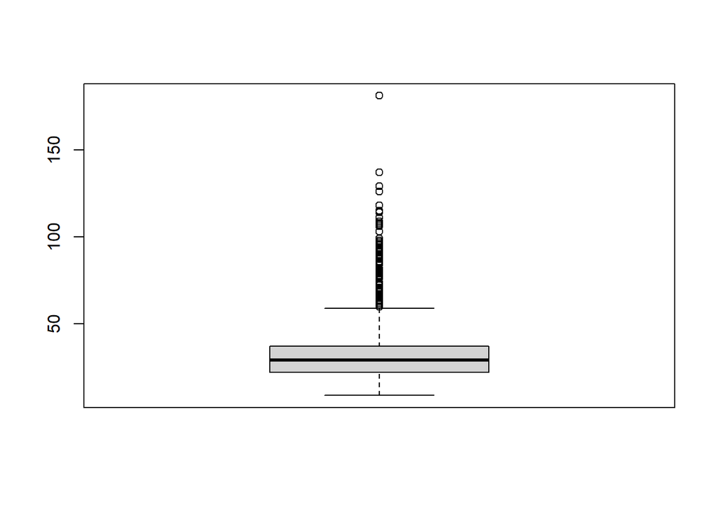

```r
boxplot(ispu_harian_gabung$O3)
```

```r
boxplot.stats(ispu_harian_gabung$O3)$out
```

```
##   [1]  63.4  79.4  63.0  63.0  68.0  65.0  63.0  69.0  68.0  60.0  76.0  64.0
##  [13]  65.0  68.0  67.0  60.0  61.0  62.0  86.0  67.0  69.0  62.0  79.0  80.0
##  [25]  77.0  69.0  70.0 109.0 137.0  76.0  70.0  69.0  73.0  62.0  80.0  95.0
##  [37]  78.0 118.0 111.0  81.0  91.0  93.0  88.0  84.0  69.0  82.0  99.0  70.0
##  [49]  61.0  82.0  77.0  72.0  82.0  76.0  73.0  74.0  81.0  63.0  65.0  72.0
##  [61]  87.0  81.0  77.0  89.0  64.0  71.0  76.0  82.0  65.0  76.0  72.0  92.0
##  [73]  87.0  62.0  67.0  71.0  71.0  82.0  99.0  70.0  72.0  68.0  77.0  60.0
##  [85]  69.0  76.0  82.0  72.0  84.0  87.0 106.0 126.0  60.0  61.0  71.0  74.0
##  [97]  95.0 107.0  84.0  84.0  84.0  65.0  65.0  84.0  98.0  94.0 114.0  96.0
## [109]  67.0  94.0  91.0  85.0 118.0  90.0  86.0  95.0 115.0  91.0  84.0 129.0
## [121]  82.0  79.0  87.0 114.0  97.0 103.0  82.0  80.0  97.0  76.0  80.0  63.0
## [133] 181.0 108.0  84.0  66.0  69.0  65.0  79.0  81.0  82.0  66.0  74.0
```

```r
ispu_harian_gabung %>%
  filter(O3 %in% boxplot.stats(O3)$out)
```

| Tanggal | PM2.5 | PM10 | SO2 | CO | O3 | NO2 | MAX | CRITICAL | CATEGORY |
| --- | --- | --- | --- | --- | --- | --- | --- | --- | --- |
| 2021-01-23 | 103.2 | 80.6 | 19.2 | 43.8 | 63.4 | 17.0 | 103.2 | PM2.5 | Unhealthly |
| 2021-01-25 | 85.6 | 58.1 | 16.5 | 26.6 | 79.4 | 12.1 | 85.6 | PM2.5 | Moderate |
| 2022-01-13 | 62.0 | 38.0 | 52.0 | 15.0 | 63.0 | 32.0 | 63.0 | O3 | Moderate |
| 2022-01-14 | 63.0 | 46.0 | 48.0 | 15.0 | 63.0 | 32.0 | 63.0 | PM2.5 | Moderate |
| 2022-01-15 | 69.0 | 55.0 | 51.0 | 15.0 | 68.0 | 29.0 | 69.0 | PM2.5 | Moderate |
| 2022-01-16 | 102.0 | 67.0 | 47.0 | 20.0 | 65.0 | 32.0 | 102.0 | PM2.5 | Unhealthly |
| 2022-01-17 | 93.0 | 67.0 | 44.0 | 19.0 | 63.0 | 28.0 | 93.0 | PM2.5 | Moderate |
| 2022-01-19 | 61.0 | 45.0 | 45.0 | 15.0 | 69.0 | 22.0 | 69.0 | O3 | Moderate |
| 2022-01-20 | 57.0 | 40.0 | 55.0 | 14.0 | 68.0 | 24.0 | 68.0 | O3 | Moderate |
| 2022-01-28 | 84.0 | 63.0 | 52.0 | 12.0 | 60.0 | 28.0 | 84.0 | PM2.5 | Moderate |

[output cut: 133 more lines]

#### A.2.4.6. Variabel NO2

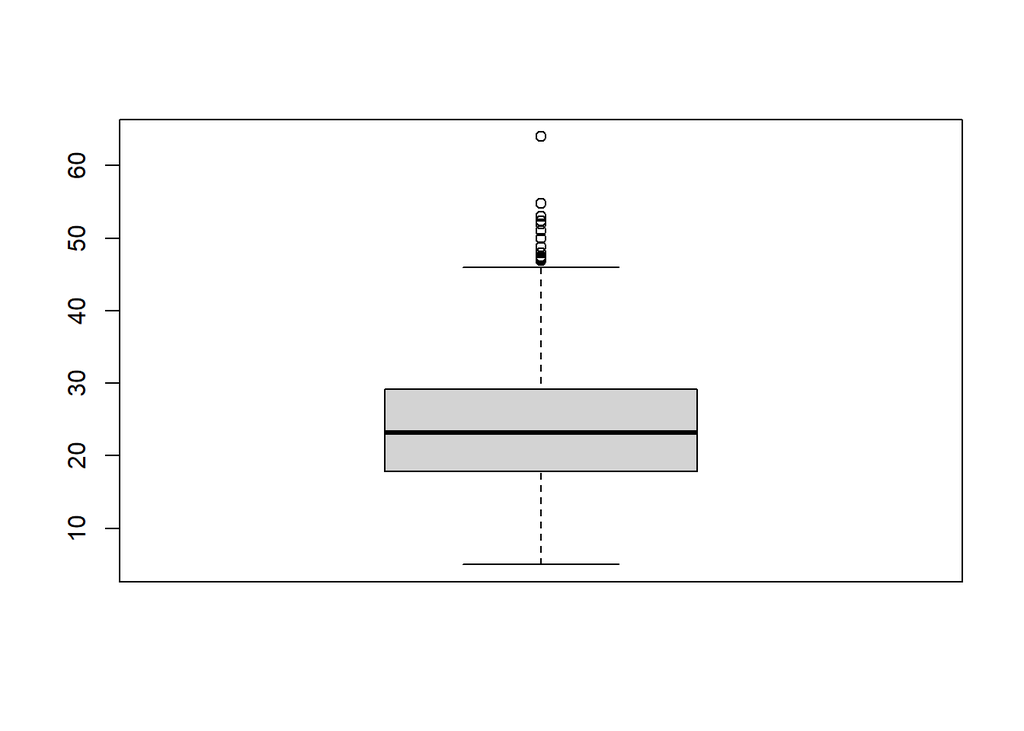

```r
boxplot(ispu_harian_gabung$NO2)
```

```r
boxplot.stats(ispu_harian_gabung$NO2)$out
```

```
##  [1] 52.4 54.8 47.4 53.0 47.0 48.8 64.0 47.2 46.9 47.0 47.2 53.0 50.0 52.0 51.0
## [16] 51.0 50.0 50.0 47.0 48.0 47.0
```

```r
ispu_harian_gabung %>%
  filter(NO2 %in% boxplot.stats(NO2)$out)
```

| Tanggal | PM2.5 | PM10 | SO2 | CO | O3 | NO2 | MAX | CRITICAL | CATEGORY |
| --- | --- | --- | --- | --- | --- | --- | --- | --- | --- |
| 2024-02-13 | 59.8 | 44.4 | 40.8 | 8.6 | 21.8 | 52.4 | 59.8 | PM2.5 | Moderate |
| 2024-02-14 | 46.4 | 36.6 | 40.6 | 9.8 | 23.8 | 54.8 | 54.8 | NO2 | Moderate |
| 2024-03-10 | 83.8 | 59.6 | 34.8 | 30.6 | 19.6 | 47.4 | 83.8 | PM2.5 | Moderate |
| 2024-03-23 | 108.0 | 64.2 | 34.2 | 31.8 | 29.2 | 53.0 | 108.0 | PM2.5 | Unhealthly |
| 2024-04-05 | 110.2 | 72.6 | 34.2 | 31.8 | 27.4 | 47.0 | 110.2 | PM2.5 | Unhealthly |
| 2024-11-17 | 110.4 | 66.4 | 46.4 | 32.2 | 28.4 | 48.8 | 110.4 | PM2.5 | Unhealthly |
| 2024-12-07 | 87.4 | 61.4 | 59.8 | 33.2 | 17.2 | 64.0 | 87.4 | PM2.5 | Moderate |
| 2025-06-19 | 81.4 | 47.8 | 30.6 | 24.2 | 14.4 | 47.2 | 81.4 | PM2.5 | Moderate |
| 2025-06-29 | 92.0 | 60.4 | 29.4 | 20.4 | 14.4 | 46.9 | 92.0 | PM2.5 | Moderate |
| 2025-08-21 | 81.4 | 51.3 | 39.0 | 17.8 | 20.2 | 47.0 | 81.4 | PM2.5 | Moderate |

[output cut: 11 more lines]

## A.3. Agregasi Data ISPU Harian -> ISPU Bulanan

```r
# Agregasi data ispu_harian_gabung menjadi data ispu_bulanan
ispu_bulanan <- ispu_harian_gabung %>%
  mutate(Month = floor_date(Tanggal, "month")) %>%
  group_by(Month) %>%
  summarise(
    PM2.5 = mean(PM2.5, na.rm = TRUE),
    PM10 = mean(PM10, na.rm = TRUE),
    SO2 = mean(SO2, na.rm = TRUE),
    CO = mean(CO, na.rm = TRUE),
    O3 = mean(O3, na.rm = TRUE),
    NO2 = mean(NO2, na.rm = TRUE),

    DAYS = n()
  )

# Menambahkan variabel MAX, CRITICAL, dan CATEGORY di ispu bulanan
ispu_bulanan$MAX <- pmax(ispu_bulanan$PM2.5, ispu_bulanan$PM10, ispu_bulanan$SO2, ispu_bulanan$CO, ispu_bulanan$O3, ispu_bulanan$NO2, na.rm = TRUE)

ispu_bulanan$CRITICAL <- colnames(
  ispu_bulanan[,c("PM2.5","PM10","SO2","CO","O3","NO2")]
)[max.col(
  ispu_bulanan[,c("PM2.5","PM10","SO2","CO","O3","NO2")],
  ties.method = "first"
)]

ispu_bulanan$CATEGORY <- case_when(
  ispu_bulanan$MAX <= 50 ~ "Good",
  ispu_bulanan$MAX <= 100 ~ "Moderate",
  ispu_bulanan$MAX <= 200 ~ "Unhealthly",
  ispu_bulanan$MAX <= 300 ~ "Very Unhealthly",
  TRUE ~ "Hazardous"
)
```

```r
# Mengecek apakah data ispu sudah diubah ke bulanan
head(ispu_bulanan)
```

| Month | PM2.5 | PM10 | SO2 | CO | O3 | NO2 | DAYS | MAX | CRITICAL | CATEGORY |
| --- | --- | --- | --- | --- | --- | --- | --- | --- | --- | --- |
| 2021-01-01 | 59.41613 | 40.70000 | 19.39032 | 15.00000 | 44.70645 | 8.783871 | 31 | 59.41613 | PM2.5 | Moderate |
| 2021-02-01 | 56.67857 | 36.93571 | 30.59286 | 11.26429 | 25.46786 | 15.535714 | 28 | 56.67857 | PM2.5 | Moderate |
| 2021-03-01 | 75.22581 | 50.34839 | 31.72258 | 13.37097 | 29.40968 | 19.164516 | 31 | 75.22581 | PM2.5 | Moderate |
| 2021-04-01 | 79.31667 | 53.01333 | 32.86667 | 12.63333 | 31.40667 | 20.976667 | 30 | 79.31667 | PM2.5 | Moderate |
| 2021-05-01 | 79.30000 | 54.90645 | 34.21290 | 11.34839 | 34.42258 | 19.016129 | 31 | 79.30000 | PM2.5 | Moderate |
| 2021-06-01 | 90.93667 | 61.40667 | 39.13667 | 13.77667 | 30.40667 | 27.126667 | 30 | 90.93667 | PM2.5 | Moderate |

```r
summary(ispu_bulanan)
```

```
##      Month                PM2.5             PM10            SO2
##  Min.   :2021-01-01   Min.   : 42.34   Min.   :32.15   Min.   :18.82
##  1st Qu.:2022-03-16   1st Qu.: 66.85   1st Qu.:45.14   1st Qu.:34.15
##  Median :2023-06-01   Median : 81.25   Median :53.96   Median :39.08
##  Mean   :2023-06-01   Mean   : 78.22   Mean   :52.36   Mean   :38.63
##  3rd Qu.:2024-08-16   3rd Qu.: 87.98   3rd Qu.:58.97   3rd Qu.:43.80
##  Max.   :2025-11-01   Max.   :110.39   Max.   :68.94   Max.   :54.03
##        CO              O3             NO2              DAYS
##  Min.   : 8.60   Min.   :15.66   Min.   : 8.784   Min.   :28.00
##  1st Qu.:12.25   1st Qu.:22.92   1st Qu.:19.234   1st Qu.:30.00
##  Median :14.11   Median :29.97   Median :24.003   Median :31.00
##  Mean   :14.62   Mean   :33.10   Mean   :23.990   Mean   :30.42
##  3rd Qu.:17.21   3rd Qu.:35.78   3rd Qu.:28.928   3rd Qu.:31.00
##  Max.   :26.00   Max.   :85.55   Max.   :34.800   Max.   :31.00
##       MAX           CRITICAL           CATEGORY
##  Min.   : 42.34   Length:59          Length:59
##  1st Qu.: 66.85   Class :character   Class :character
##  Median : 81.25   Mode  :character   Mode  :character
##  Mean   : 78.22
##  3rd Qu.: 87.98
##  Max.   :110.39
```

## A.4. Agregasi Data Cuaca Harian -> Cuaca Bulanan

```r
# Mengubah data cuaca harian menjadi bentuk bulanan
cuaca_bulanan <- cuaca_harian %>%
  mutate(Month = floor_date(Tanggal, "month")) %>%
  group_by(Month) %>%
  summarise(
    TEMP = mean(TEMP, na.rm = TRUE),
    HUM = mean(HUM, na.rm = TRUE),
    RAIN = mean(RAIN, na.rm = TRUE),
    CC = mean(CC, na.rm = TRUE),
    WSPM = mean(WSPM, na.rm = TRUE),
    PRES = mean(PRES, na.rm = TRUE)
  )

# Membuat variabel kategori hujan di data cuaca_bulanan
cuaca_bulanan <- cuaca_bulanan %>%
  mutate(
    RAIN_CATEGORY = case_when(
      RAIN == 0 ~ "No Rain",
      RAIN < 5 ~ "Very Light Rain",
      RAIN < 20 ~ "Light Rain",
      RAIN < 50 ~ "Moderate Rain",
      RAIN < 100 ~ "Heavy Rain",
      TRUE ~ "Very Heavy Rain"
    )
  )

# Membuat variabel kategori kelembaban di cuaca_bulanan
cuaca_bulanan <- cuaca_bulanan %>%
  mutate(
    HUM_CATEGORY = case_when(
      HUM < 45 ~ "Low Humidity",
      HUM < 65 ~ "Optimal Humidity",
      TRUE ~ "High Humidity"
    )
  )
```

```r
# Mengecek apakah data cuaca sudah dalam bentuk bulanan
head(cuaca_bulanan)
```

| Month | TEMP | HUM | RAIN | CC | WSPM | PRES | RAIN_CATEGORY | HUM_CATEGORY |
| --- | --- | --- | --- | --- | --- | --- | --- | --- |
| 2021-01-01 | 25.51419 | 87.84516 | 13.627097 | 96.71613 | 8.034194 | 1006.036 | Light Rain | High Humidity |
| 2021-02-01 | 25.53357 | 88.86429 | 15.175000 | 93.26429 | 7.757143 | 1006.685 | Light Rain | High Humidity |
| 2021-03-01 | 26.28258 | 85.76774 | 8.271613 | 89.02581 | 6.303871 | 1006.293 | Light Rain | High Humidity |
| 2021-04-01 | 26.53733 | 84.71333 | 5.981333 | 71.64000 | 5.999333 | 1007.118 | Light Rain | High Humidity |
| 2021-05-01 | 27.04903 | 84.36774 | 6.258065 | 64.81290 | 5.756774 | 1006.175 | Light Rain | High Humidity |
| 2021-06-01 | 26.29000 | 86.43333 | 6.184000 | 72.28667 | 5.214000 | 1007.672 | Light Rain | High Humidity |

```r
summary(cuaca_bulanan)
```

```
##      Month                 TEMP            HUM             RAIN
##  Min.   :2021-01-01   Min.   :25.51   Min.   :66.24   Min.   : 0.8884
##  1st Qu.:2022-03-24   1st Qu.:26.38   1st Qu.:79.48   1st Qu.: 5.1267
##  Median :2023-06-16   Median :26.87   Median :82.91   Median : 7.0226
##  Mean   :2023-06-16   Mean   :26.84   Mean   :81.57   Mean   : 7.2523
##  3rd Qu.:2024-09-08   3rd Qu.:27.23   3rd Qu.:84.85   3rd Qu.: 9.5929
##  Max.   :2025-12-01   Max.   :28.85   Max.   :88.86   Max.   :15.1750
##        CC             WSPM            PRES      RAIN_CATEGORY
##  Min.   :49.54   Min.   :4.435   Min.   :1005   Length:60
##  1st Qu.:69.13   1st Qu.:5.516   1st Qu.:1006   Class :character
##  Median :85.76   Median :6.222   Median :1007   Mode  :character
##  Mean   :80.62   Mean   :6.422   Mean   :1007
##  3rd Qu.:93.29   3rd Qu.:7.215   3rd Qu.:1007
##  Max.   :97.49   Max.   :9.769   Max.   :1008
##  HUM_CATEGORY
##  Length:60
##  Class :character
##  Mode  :character
##
##
##
```

## A.5. Menyiapkan Data ISPA Bulanan

```r
str(data_ispa)
```

```
## 'data.frame':    60 obs. of  3 variables:
##  $ X        : int  1 2 3 4 5 6 7 8 9 10 ...
##  $ Case_ISPA: num  35 37 40 42 39 60 50 32 45 45 ...
##  $ bulan    : chr  "2021-01-01" "2021-02-01" "2021-03-01" "2021-04-01" ...
```

```r
# Mengubah nama variabel bulan
# data_ispa <- data_ispa %>% rename(Month = Bulan)

# Mengubah tipe data variabel bulan
data_ispa$Month <- ymd(data_ispa$bulan)

# Mengambil variabel yang ingin diambil
data_ispa <- data_ispa %>% select(Month, Case_ISPA)
```

```r
names(ispu_bulanan)
```

```
##  [1] "Month"    "PM2.5"    "PM10"     "SO2"      "CO"       "O3"
##  [7] "NO2"      "DAYS"     "MAX"      "CRITICAL" "CATEGORY"
```

```r
names(data_ispa)
```

```
## [1] "Month"     "Case_ISPA"
```

```r
names(cuaca_bulanan)
```

```
## [1] "Month"         "TEMP"          "HUM"           "RAIN"
## [5] "CC"            "WSPM"          "PRES"          "RAIN_CATEGORY"
## [9] "HUM_CATEGORY"
```

```r
str(cuaca_bulanan)
```

```
## tibble [60 × 9] (S3: tbl_df/tbl/data.frame)
##  $ Month        : Date[1:60], format: "2021-01-01" "2021-02-01" ...
##  $ TEMP         : num [1:60] 25.5 25.5 26.3 26.5 27 ...
##  $ HUM          : num [1:60] 87.8 88.9 85.8 84.7 84.4 ...
##  $ RAIN         : num [1:60] 13.63 15.18 8.27 5.98 6.26 ...
##  $ CC           : num [1:60] 96.7 93.3 89 71.6 64.8 ...
##  $ WSPM         : num [1:60] 8.03 7.76 6.3 6 5.76 ...
##  $ PRES         : num [1:60] 1006 1007 1006 1007 1006 ...
##  $ RAIN_CATEGORY: chr [1:60] "Light Rain" "Light Rain" "Light Rain" "Light Rain" ...
##  $ HUM_CATEGORY : chr [1:60] "High Humidity" "High Humidity" "High Humidity" "High Humidity" ...
```

## A.6. Gabungkan Keseluruhan Data ke Skala Bulanan

```r
# Menggabungkan data ISPU bulanan, cuaca bulanan, dan data ISPA bulanan menjadi satu data
data_bulanan <- ispu_bulanan %>%
  inner_join(data_ispa, by = "Month") %>%
  inner_join(cuaca_bulanan, by = "Month") %>% select(Month, PM2.5, PM10, SO2, CO, O3, NO2, MAX, CRITICAL, CATEGORY,
         TEMP, RAIN, HUM, CC, WSPM, PRES, RAIN_CATEGORY, HUM_CATEGORY, Case_ISPA)

# data_bulanan menjadi dataset final untuk melanjutkan ke tahap EDA, Feature Engineering & Modeling
write.csv(data_bulanan, "data_bulanan.csv", row.names = FALSE)
```

```r
str(data_bulanan)
```

```
## tibble [59 × 19] (S3: tbl_df/tbl/data.frame)
##  $ Month        : Date[1:59], format: "2021-01-01" "2021-02-01" ...
##  $ PM2.5        : num [1:59] 59.4 56.7 75.2 79.3 79.3 ...
##  $ PM10         : num [1:59] 40.7 36.9 50.3 53 54.9 ...
##  $ SO2          : num [1:59] 19.4 30.6 31.7 32.9 34.2 ...
##  $ CO           : num [1:59] 15 11.3 13.4 12.6 11.3 ...
##  $ O3           : num [1:59] 44.7 25.5 29.4 31.4 34.4 ...
##  $ NO2          : num [1:59] 8.78 15.54 19.16 20.98 19.02 ...
##  $ MAX          : num [1:59] 59.4 56.7 75.2 79.3 79.3 ...
##  $ CRITICAL     : chr [1:59] "PM2.5" "PM2.5" "PM2.5" "PM2.5" ...
##  $ CATEGORY     : chr [1:59] "Moderate" "Moderate" "Moderate" "Moderate" ...
##  $ TEMP         : num [1:59] 25.5 25.5 26.3 26.5 27 ...
##  $ RAIN         : num [1:59] 13.63 15.18 8.27 5.98 6.26 ...
##  $ HUM          : num [1:59] 87.8 88.9 85.8 84.7 84.4 ...
##  $ CC           : num [1:59] 96.7 93.3 89 71.6 64.8 ...
##  $ WSPM         : num [1:59] 8.03 7.76 6.3 6 5.76 ...
##  $ PRES         : num [1:59] 1006 1007 1006 1007 1006 ...
##  $ RAIN_CATEGORY: chr [1:59] "Light Rain" "Light Rain" "Light Rain" "Light Rain" ...
##  $ HUM_CATEGORY : chr [1:59] "High Humidity" "High Humidity" "High Humidity" "High Humidity" ...
##  $ Case_ISPA    : num [1:59] 35 37 40 42 39 60 50 32 45 45 ...
```

```r
# Ubah tipe data pada variabel Month
data_bulanan$Month <- as.Date(
  paste0(data_bulanan$Month, "-01")
)
```

```r
str(data_bulanan)
```

```
## tibble [59 × 19] (S3: tbl_df/tbl/data.frame)
##  $ Month        : Date[1:59], format: "2021-01-01" "2021-02-01" ...
##  $ PM2.5        : num [1:59] 59.4 56.7 75.2 79.3 79.3 ...
##  $ PM10         : num [1:59] 40.7 36.9 50.3 53 54.9 ...
##  $ SO2          : num [1:59] 19.4 30.6 31.7 32.9 34.2 ...
##  $ CO           : num [1:59] 15 11.3 13.4 12.6 11.3 ...
##  $ O3           : num [1:59] 44.7 25.5 29.4 31.4 34.4 ...
##  $ NO2          : num [1:59] 8.78 15.54 19.16 20.98 19.02 ...
##  $ MAX          : num [1:59] 59.4 56.7 75.2 79.3 79.3 ...
##  $ CRITICAL     : chr [1:59] "PM2.5" "PM2.5" "PM2.5" "PM2.5" ...
##  $ CATEGORY     : chr [1:59] "Moderate" "Moderate" "Moderate" "Moderate" ...
##  $ TEMP         : num [1:59] 25.5 25.5 26.3 26.5 27 ...
##  $ RAIN         : num [1:59] 13.63 15.18 8.27 5.98 6.26 ...
##  $ HUM          : num [1:59] 87.8 88.9 85.8 84.7 84.4 ...
##  $ CC           : num [1:59] 96.7 93.3 89 71.6 64.8 ...
##  $ WSPM         : num [1:59] 8.03 7.76 6.3 6 5.76 ...
##  $ PRES         : num [1:59] 1006 1007 1006 1007 1006 ...
##  $ RAIN_CATEGORY: chr [1:59] "Light Rain" "Light Rain" "Light Rain" "Light Rain" ...
##  $ HUM_CATEGORY : chr [1:59] "High Humidity" "High Humidity" "High Humidity" "High Humidity" ...
##  $ Case_ISPA    : num [1:59] 35 37 40 42 39 60 50 32 45 45 ...
```

# Bagian B. Exploratory Data Analysis (EDA)

## B.1. Univariate Numerical

```r
library(ggplot2)
```

### B.1.1. PM2.5 Distribution in Jakarta (Histogram)

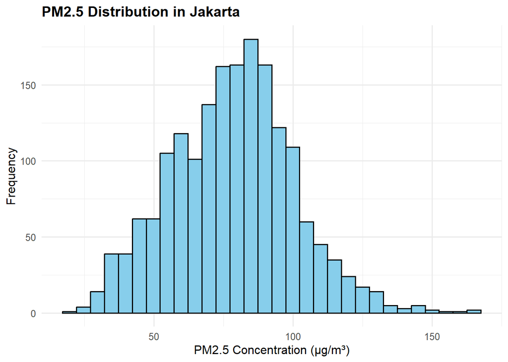

```r
ggplot(ispu_cuaca_harian, aes(x = PM2.5)) +
  geom_histogram(
    bins = 30,
    fill = "skyblue",
    color = "black"
  ) +
  labs(
    title = "PM2.5 Distribution in Jakarta",
    x = "PM2.5 Concentration (µg/m³)",
    y = "Frequency"
  ) +
  theme_minimal(base_size = 12) +

  theme(
    plot.title = element_text(face = "bold"),
    axis.text.x = element_text(angle = 0)
  )
```

### B.1.2. Boxplot of PM10 in Jakarta (Boxplot)

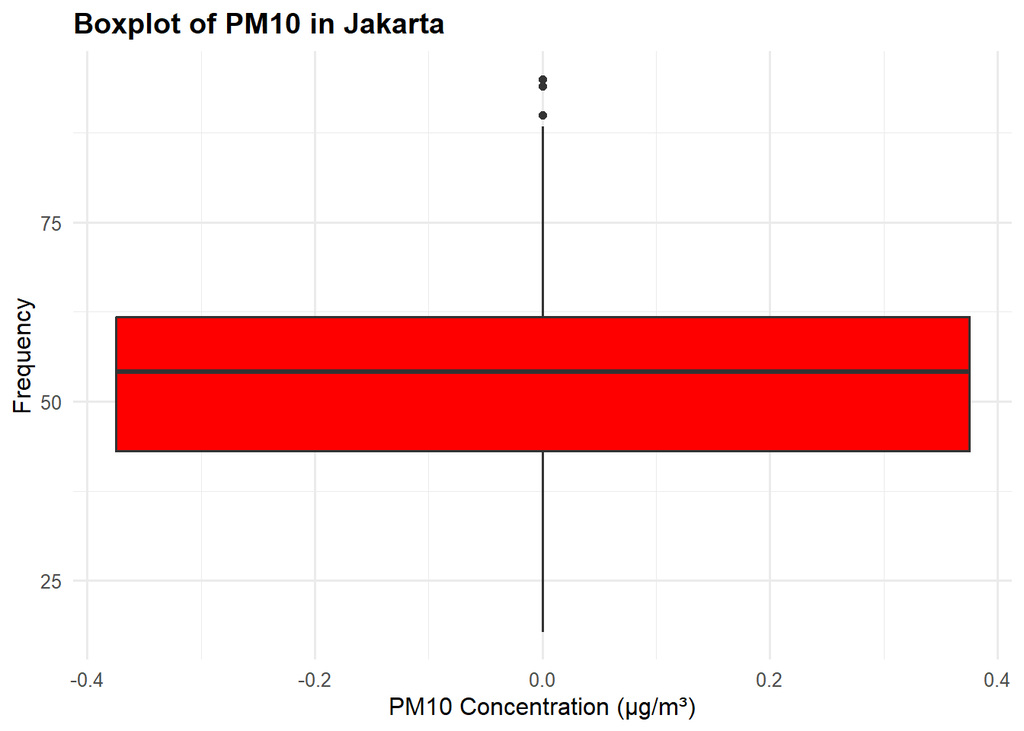

```r
ggplot(ispu_cuaca_harian,
       aes(y = PM10)) +
  geom_boxplot(fill = "red") +
  labs(
    title = "Boxplot of PM10 in Jakarta",
    x = "PM10 Concentration (µg/m³)",
    y = "Frequency"
  ) +

  theme_minimal(base_size = 12) +

  theme(
    plot.title = element_text(face = "bold"),
    axis.text.x = element_text(angle = 0)
  )
```

### B.1.3. Daily Trend of PM2.5 in Jakarta (Time Series Plot)

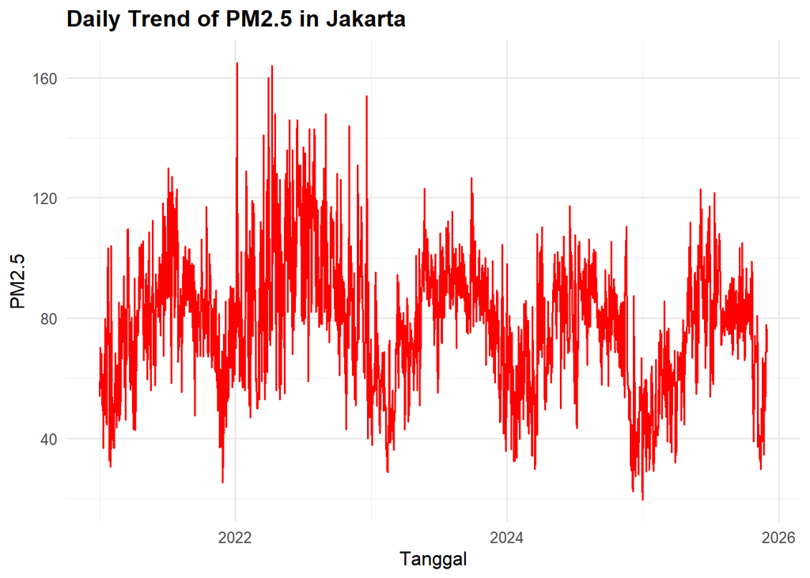

```r
ggplot(ispu_cuaca_harian,
       aes(x = Tanggal,
           y = PM2.5)) +
  geom_line(color = "red") +
  labs(
    title = "Daily Trend of PM2.5 in Jakarta"
  ) +
  theme_minimal(base_size = 12) +

  theme(
    plot.title = element_text(face = "bold"),
    axis.text.x = element_text(angle = 0)
  )
```

## B.2 Univariate Categorical

### B.2.1. Distribution of Air Quality Categories in Jakarta (Daily)

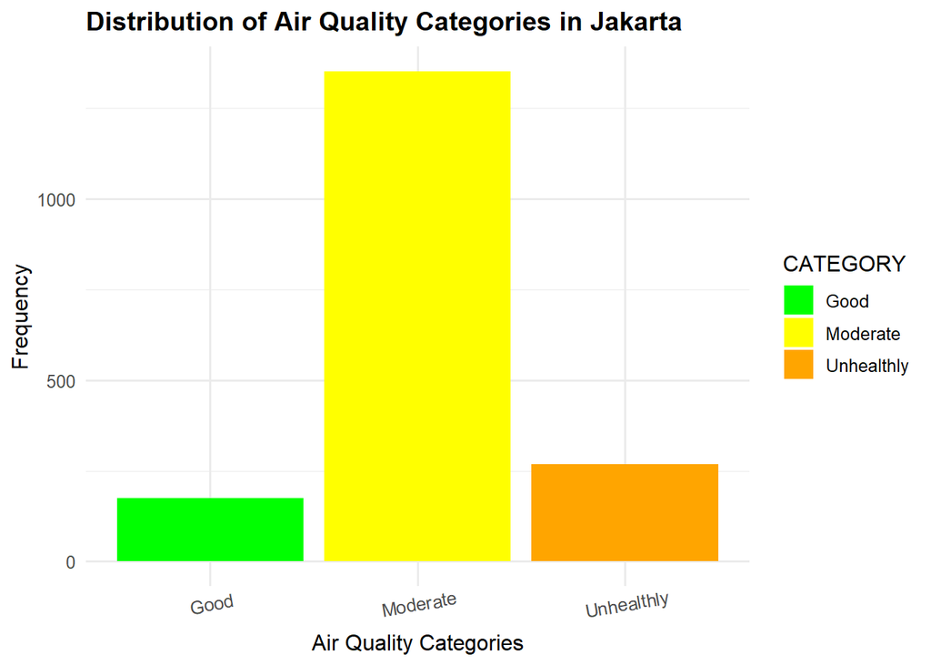

```r
ggplot(ispu_cuaca_harian,
       aes(x = CATEGORY,
           fill = CATEGORY)) +

  geom_bar() +

  labs(
    title = "Distribution of Air Quality Categories in Jakarta",
    x = "Air Quality Categories",
    y = "Frequency"
  ) +
  scale_fill_manual( values = c(
    "Good" = "green",
    "Moderate" = "yellow",
    "Unhealthly" = "orange",
    "Very Unhealthly" = "red",
    "Hazardous" = "darkred"
  )) +
  theme_minimal(base_size = 12) +

  theme(
    plot.title = element_text(face = "bold"),
    axis.text.x = element_text(angle = 10)
  )
```

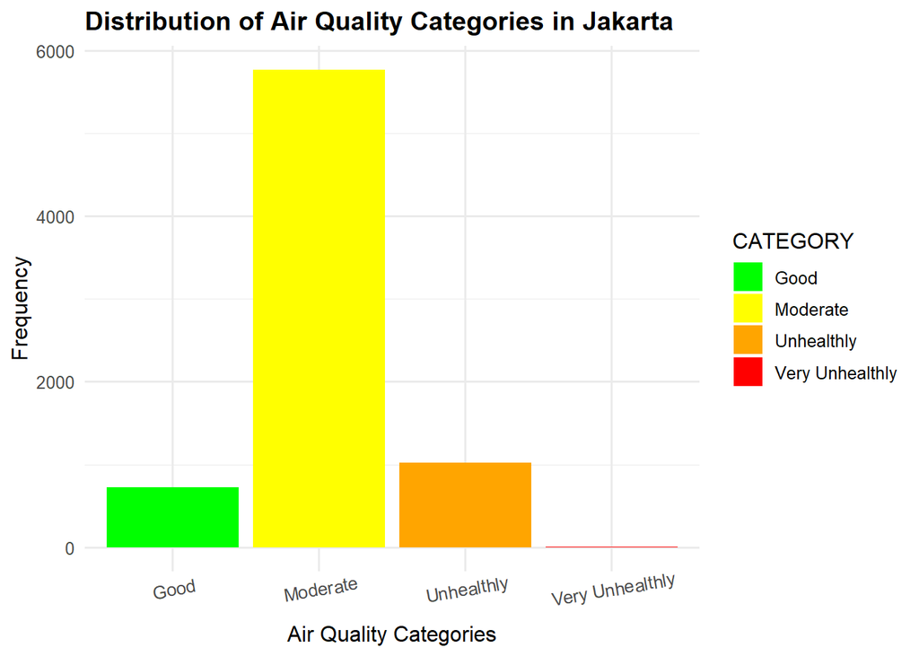

```r
ggplot(ispu_gabung,
       aes(x = CATEGORY,
           fill = CATEGORY)) +

  geom_bar() +

  labs(
    title = "Distribution of Air Quality Categories in Jakarta",
    x = "Air Quality Categories",
    y = "Frequency"
  ) +
  scale_fill_manual( values = c(
    "Good" = "green",
    "Moderate" = "yellow",
    "Unhealthly" = "orange",
    "Very Unhealthly" = "red",
    "Hazardous" = "darkred"
  )) +
  theme_minimal(base_size = 12) +

  theme(
    plot.title = element_text(face = "bold"),
    axis.text.x = element_text(angle = 10)
  )
```

### B.2.2. Distribution of Air Pollutant in Jakarta (Daily)

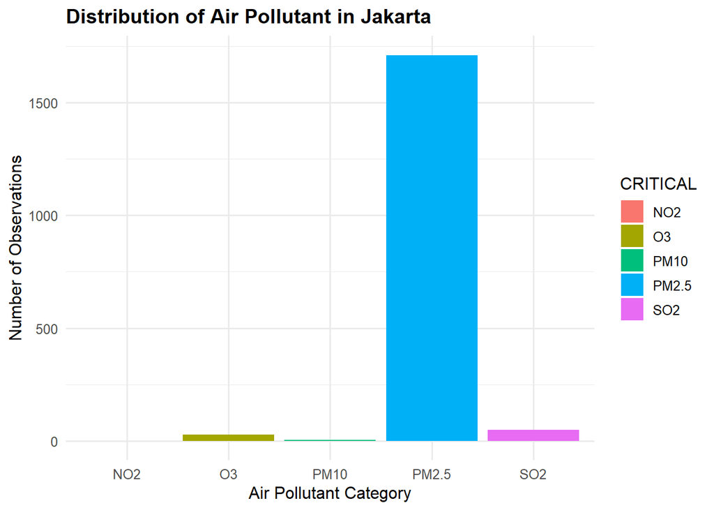

```r
ggplot(ispu_harian_gabung,
       aes(x = CRITICAL,
           fill = CRITICAL)) +

  geom_bar() +

  labs(
    title = "Distribution of Air Pollutant in Jakarta",
    x = "Air Pollutant Category",
    y = "Number of Observations"
  ) +

  theme_minimal(base_size = 12) +

  theme(
    plot.title = element_text(face = "bold"),
  )
```

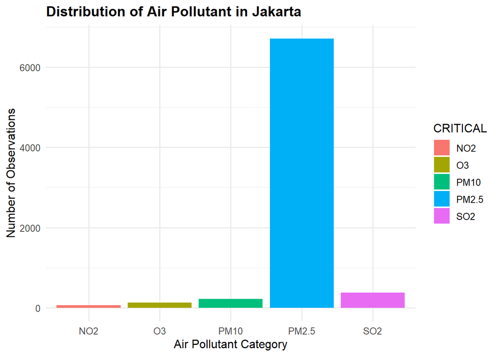

```r
ggplot(ispu_gabung,
       aes(x = CRITICAL,
           fill = CRITICAL)) +

  geom_bar() +

  labs(
    title = "Distribution of Air Pollutant in Jakarta",
    x = "Air Pollutant Category",
    y = "Number of Observations"
  ) +

  theme_minimal(base_size = 12) +

  theme(
    plot.title = element_text(face = "bold"),
  )
```